# Aides Drug

Evelyn Sanchez

30 October 2019

# Introduction

# Methods

In every one of these test we will be looking to see if there is a relationship with categorical variables and the null hypothesis. I will use the bar graph for the graphical description. In descriptive results I will provide a cross tab table. Last, but not least for the interfential results I will use a chi-square test.

Question #1 : Is the vaccine affective for the whole population?  
$H_0$: The vaccine has no effects on whether someone contracts aids or not.

$H_A$: The vaccine does affect whether one contract aids or not.

Question 2: Is vaccine affective for gals?  
$H_0$: The vaccine has no effects on women who contract aids or not.

$H_A$: The vaccine does have affect if gals contract aids or not.

Question 3: Is vaccine affective for guys?  
$H_0$: The vaccine has no effects on men who contract aids or not.

$H_A$:The vaccine does have affect if guys contract aids or not.

Question 4: Is vaccine affective for drug users?  
$H_0$: The vaccine has no effects on drug users if they contract aids or not.

$H_A$: The vaccine does have affect if drug users contract aids or not.

Question 5: Is vaccine affective LGBTQ people?  
$H_0$:The vaccine has no effects on LGBTQ users if they contract aids or not.

$H_0$:The vaccine has affect on LGBTQ users.

## Descriptive Results

### Graphical Descriptive Results

Question 1:

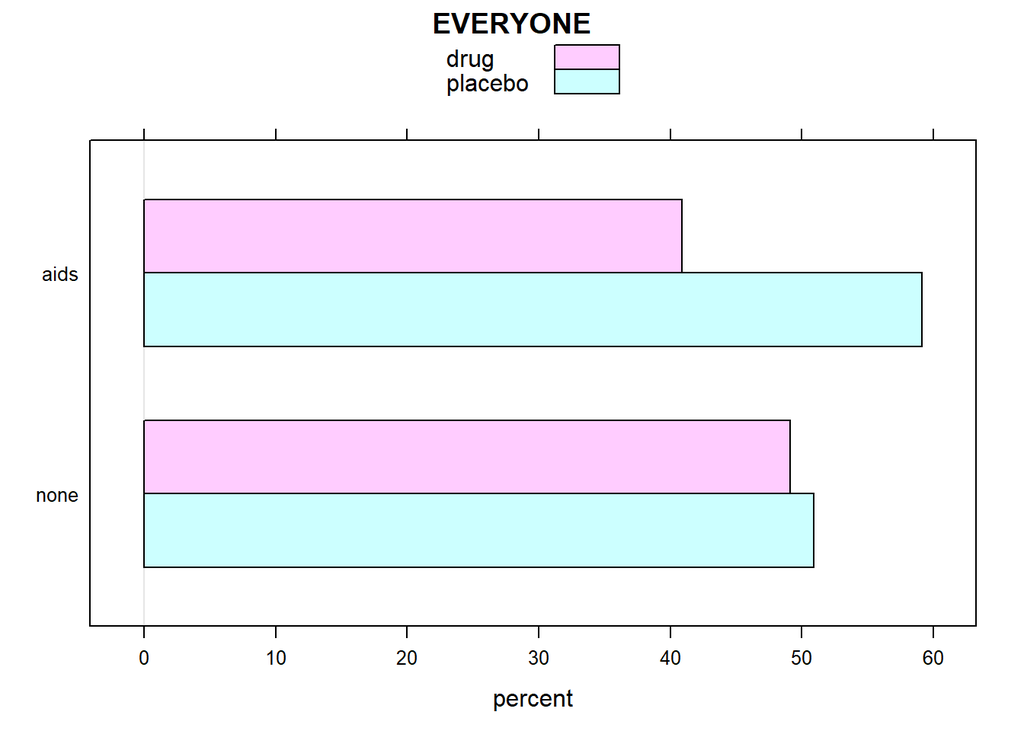

```r
barchartGC( ~ infected+treatment, type='percent',main= 'EVERYONE', horizontal = TRUE, data=avast)
```

The barchart shows that people who use the vaccine are less likely to get aids. So, people who don’t have aids use the drug or placebo; the results are very close.

Question 2:

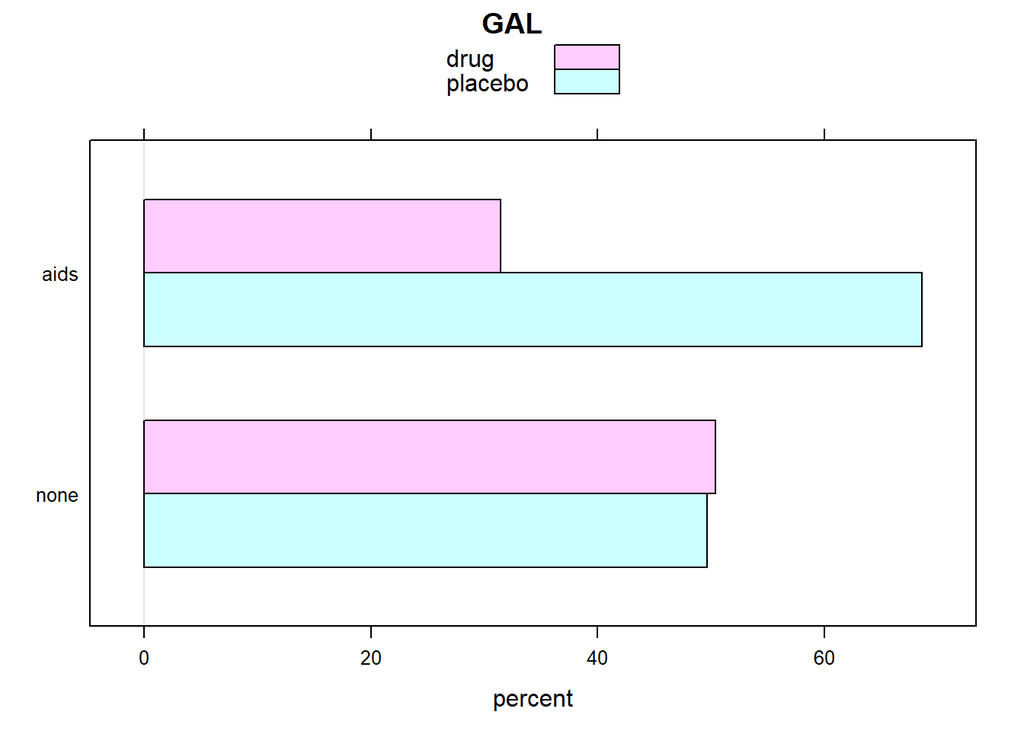

```r
barchartGC( ~ infected+treatment,type='percent',main= 'GAL',data=filter(avast, sex=='gal'),horizontal=TRUE)
```

This barchart display that gals who use the drug are less likely to get aids. So, gals who don’t have aids use the drug or placebo; the results are very close.

Question 3:

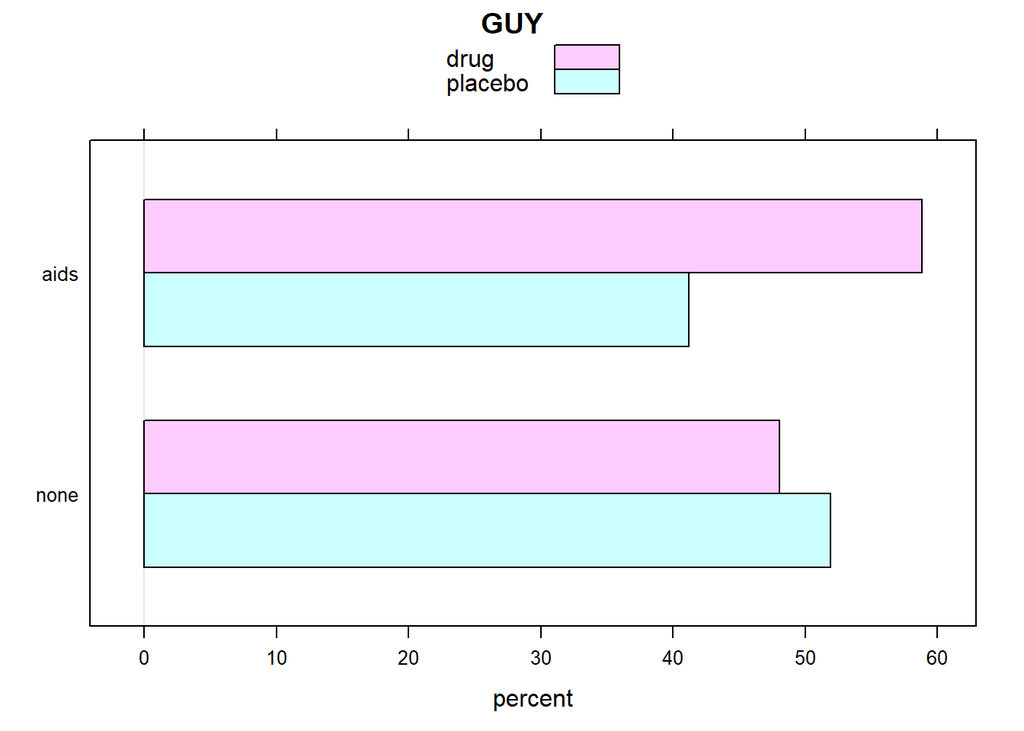

```r
barchartGC( ~ infected+treatment,type='percent',main= 'GUY',data=filter(avast, sex=='guy'),horizontal=TRUE)
```

This barchart displays that guys who use the drug are more likely to contract aids. So, guys who dont have aids that use the drug or placebo values are very close.

Question 4:

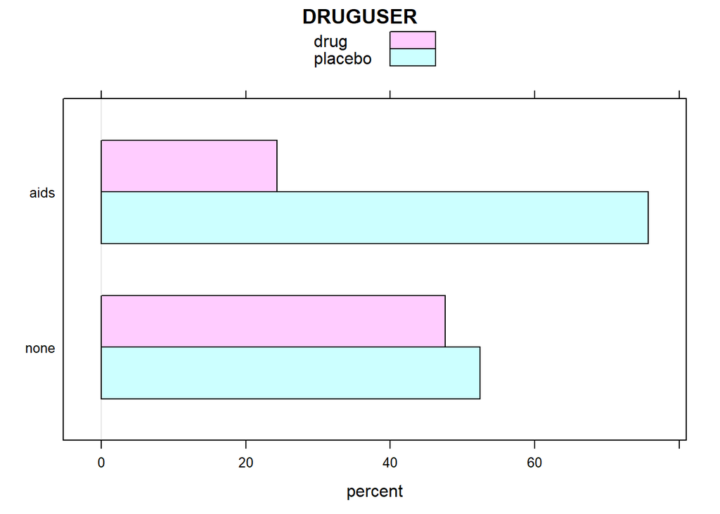

```r
barchartGC( ~ infected+treatment, type='percent', horizontal = TRUE,main= 'DRUGUSER', data=filter(avast, DrugUser=='yes'))
```

This barchart shows that people who are drug users, who take the drug to prevent aids are far more affective than the drug users who take the placebo. We can also see people who don’t have aids that use placebo and the drug are close to the same percentage. It will be departing from the expected null hypothesis.

Question 5:

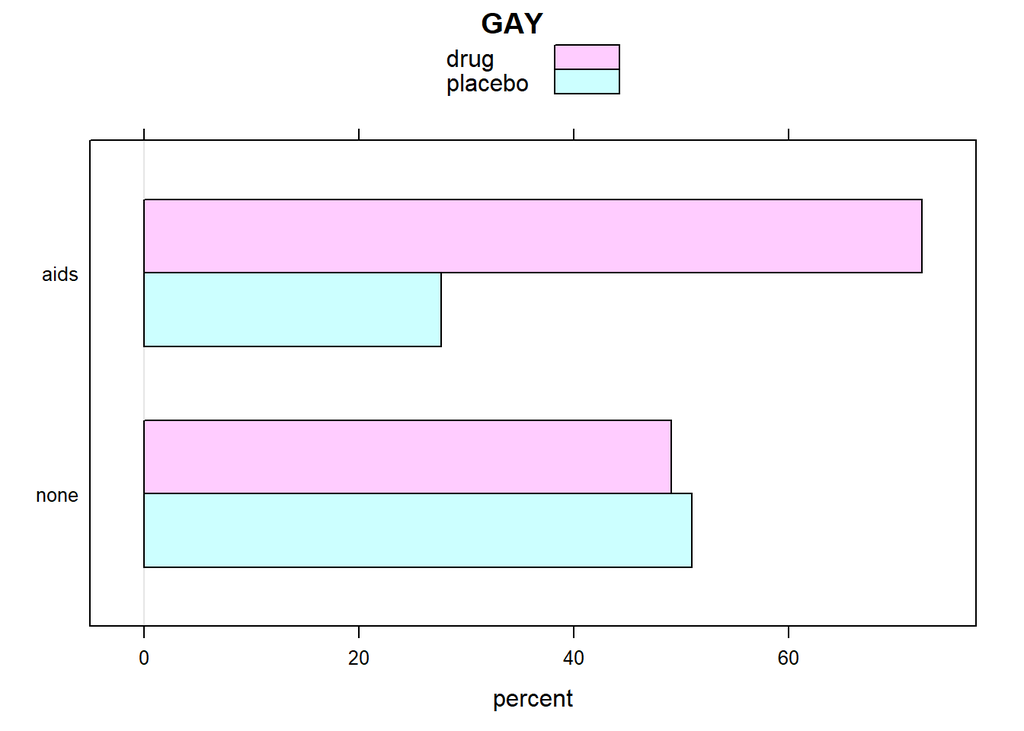

```r
barchartGC( ~ infected+treatment, type='percent', horizontal = TRUE,main= 'GAY', data=filter(avast, LGBTQ=='gay'))
```